# PAI_template.Rmd

hansj1a

Friday, February 27, 2015

# Reproducible Research: Peer Assessment 1

## Initialization and read in data

First the necessary data has to be read and converted into the right format.

```r
download.file("http://d396qusza40orc.cloudfront.net/repdata%2Fdata%2Factivity.zip","repdata_data_activity.zip")
file<-unzip("repdata_data_activity.zip")
options(max.print=99999999)
activity<-read.csv(file)
str(activity)
```

```
## 'data.frame':    17568 obs. of  3 variables:
##  $ steps   : int  NA NA NA NA NA NA NA NA NA NA ...
##  $ date    : Factor w/ 61 levels "2012-10-01","2012-10-02",..: 1 1 1 1 1 1 1 1 1 1 ...
##  $ interval: int  0 5 10 15 20 25 30 35 40 45 ...
```

```r
activity$date <- as.Date(activity$date, "%Y-%m-%d")
```

## Histogram of the total number of steps taken per day

In a second step the total number of steps taken per day is calculated and a histogram of the data is created

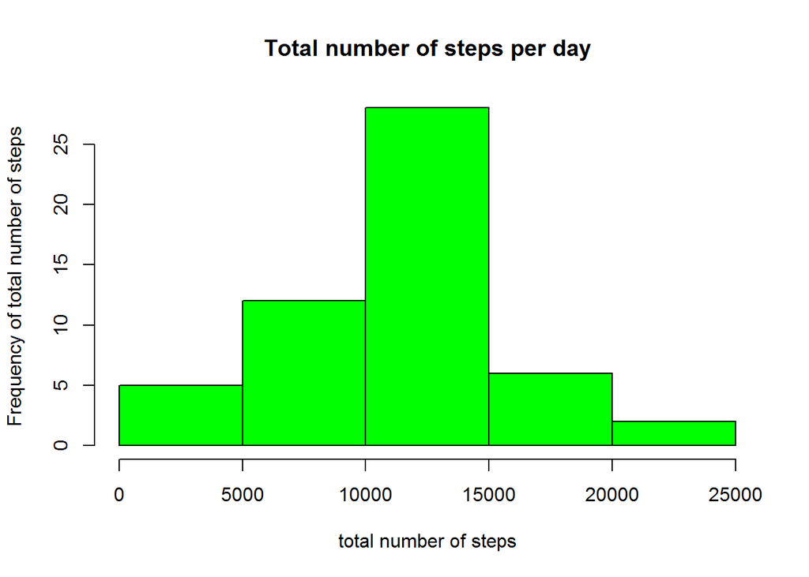

```r
totalSteps<-aggregate(steps ~ date, data = activity, sum, na.rm = TRUE)
hist(totalSteps$steps,main="Total number of steps per day",xlab="total number of steps", ylab="Frequency of total number of steps",col="green")
```

## Mean and the median of the total number of steps taken per day

In a third step mean and the median of the total number of steps taken per day are calculated

```r
meanSteps<-mean(totalSteps$steps)
medianSteps<-median(totalSteps$steps)
paste("The mean of the total number of steps taken per day is:",meanSteps)
```

```
## [1] "The mean of the total number of steps taken per day is: 10766.1886792453"
```

```r
paste("The median of the total number of steps taken per day is:",medianSteps)
```

```
## [1] "The median of the total number of steps taken per day is: 10765"
```

## Average daily activity pattern

In a 4th step a time series plot of the 5-minute interval and the average number of steps taken is made.

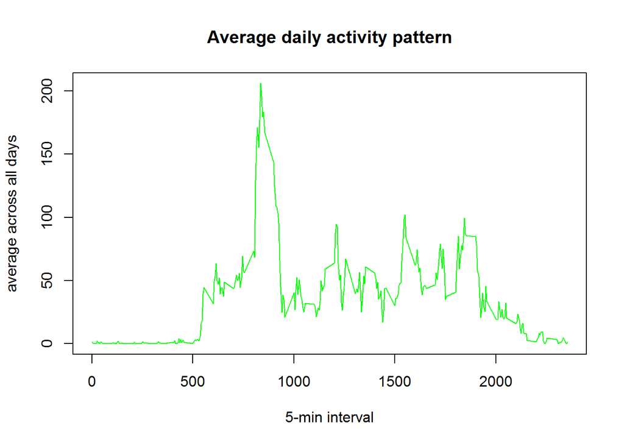

```r
timeSeries <- tapply(activity$steps, activity$interval, mean, na.rm = TRUE)
plot(row.names(timeSeries), timeSeries, type = "l", xlab = "5-min interval",
    ylab = "average across all days", main = "Average daily activity pattern",col = "green")
```

Now the 5-minute interval is determined which contain the maximum number of steps.

```r
which.max(timeSeries)
```

```
## 835
## 104
```

The 1. value characterizes the maximum interval and the 2. value identifies at which position in the array “timeSeries” this interval occurs

## Imputing missing values

Calculation of the total number of missing values in the dataset

```r
sumNAs<-sum(is.na(activity))
paste("The total number of NAs are:",sumNAs)
```

```
## [1] "The total number of NAs are: 2304"
```

Now, filling in all of the missing values in the dataset and create a new dataset that is equal to the original dataset but with the missing data filled in.

```r
newActivity<-activity
averageSteps<-aggregate(steps ~ interval, data = activity, mean)
for (i in 1:nrow(activity))
        if (is.na(activity[i,]$steps)){
                inthelp<-activity[i,]$interval
                newActivity[i,]$steps<-subset(averageSteps,interval==inthelp)$steps
        }
```

## Histogram of the total number of steps taken per day (with missing values filled in)

Again, the total number of steps taken per day is calculated and a histogram of the data is created

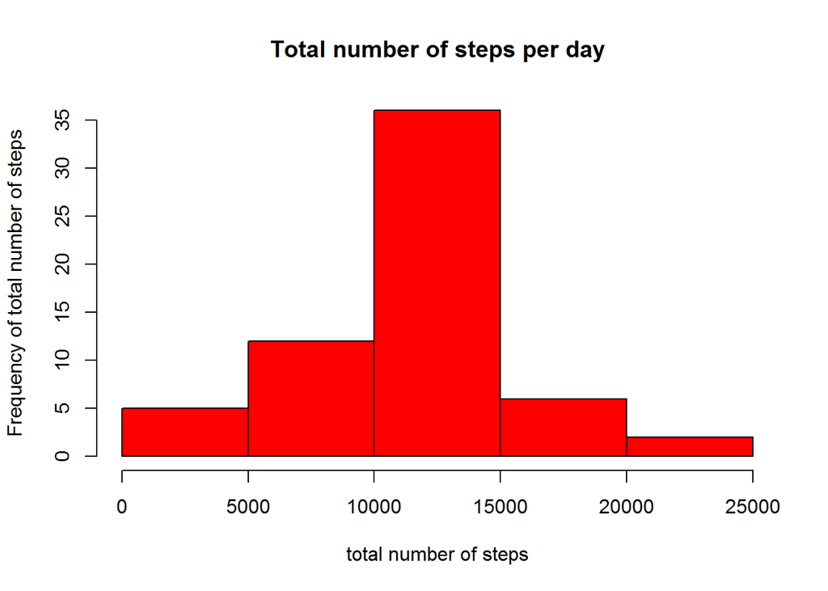

```r
totalSteps2<-aggregate(steps ~ date, data = newActivity, sum, na.rm = TRUE)
hist(totalSteps2$steps,main="Total number of steps per day",xlab="total number of steps", ylab="Frequency of total number of steps",col="red")
```

## Mean and the median of the total number of steps taken per day (with missing values filled in)

Again, mean and median of the total number of steps taken per day are calculated (this time with missing values filled in)

```r
meanSteps2<-mean(totalSteps2$steps)
medianSteps2<-median(totalSteps2$steps)
paste("The mean of the total number of steps taken per day is:",meanSteps2)
```

```
## [1] "The mean of the total number of steps taken per day is: 10766.1886792453"
```

```r
paste("The median of the total number of steps taken per day is:",medianSteps2)
```

```
## [1] "The median of the total number of steps taken per day is: 10766.1886792453"
```

```r
paste("The difference between the mean of the total steps taken per day with NA and without NA is:",meanSteps-meanSteps2)
```

```
## [1] "The difference between the mean of the total steps taken per day with NA and without NA is: 0"
```

```r
paste("The difference between the median of the total steps taken per day with NA and without NA is:",medianSteps-medianSteps2)
```

```
## [1] "The difference between the median of the total steps taken per day with NA and without NA is: -1.1886792452824"
```

## Analysis if there are differences between weekdays and weekends

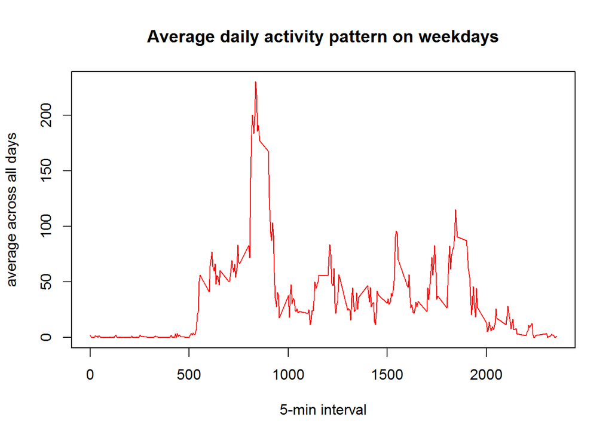

```r
newActivity$day<-weekdays(as.Date(newActivity$date))
newActivity$daytype<-""
for (i in 1:nrow(newActivity)){
        if (newActivity[i,]$day=="Samstag"||newActivity[i,]$day=="Sonntag")
             newActivity[i,]$daytype="weekend"
        else newActivity[i,]$daytype="weekday"
        }
timeSeries2 <- tapply(newActivity[newActivity$daytype=="weekday",]$steps, newActivity[newActivity$daytype=="weekday",]$interval, mean)
timeSeries3 <- tapply(newActivity[newActivity$daytype=="weekend",]$steps, newActivity[newActivity$daytype=="weekend",]$interval, mean)
plot(row.names(timeSeries2), timeSeries2, type = "l", xlab = "5-min interval",
ylab = "average across all days", main = "Average daily activity pattern on weekdays",col = "red")
```

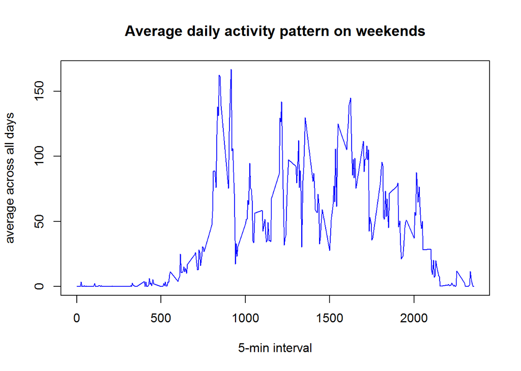

```r
plot(row.names(timeSeries3), timeSeries3, type = "l", xlab = "5-min interval",
ylab = "average across all days", main = "Average daily activity pattern on weekends",col = "blue")
```